# Final Project

Ashwin Stratton

# What do we have?

I started with a bunch of data on Twitch, Peloton, Planet Fitness, Travel Data, and Covid Data. Lets go!

Lets plug in some of our time series, and see what we have.

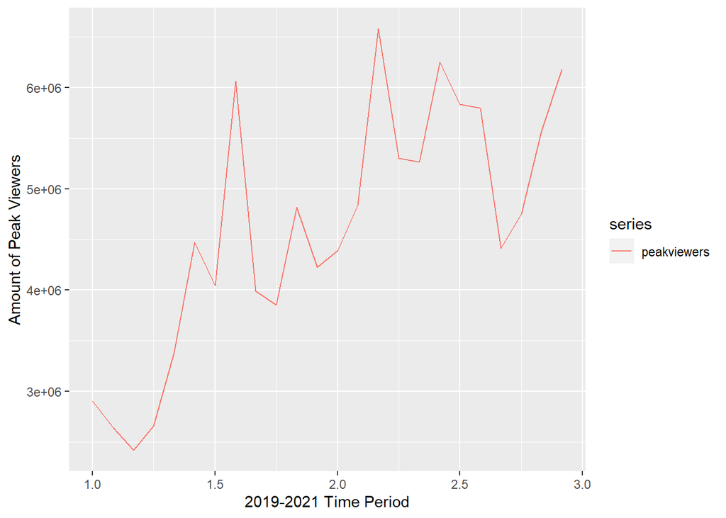

```r
ggplot()+
  geom_line() +
  autolayer(peakviewers)+
       xlab("2019-2021 Time Period")+
       ylab("Amount of Peak Viewers")
```

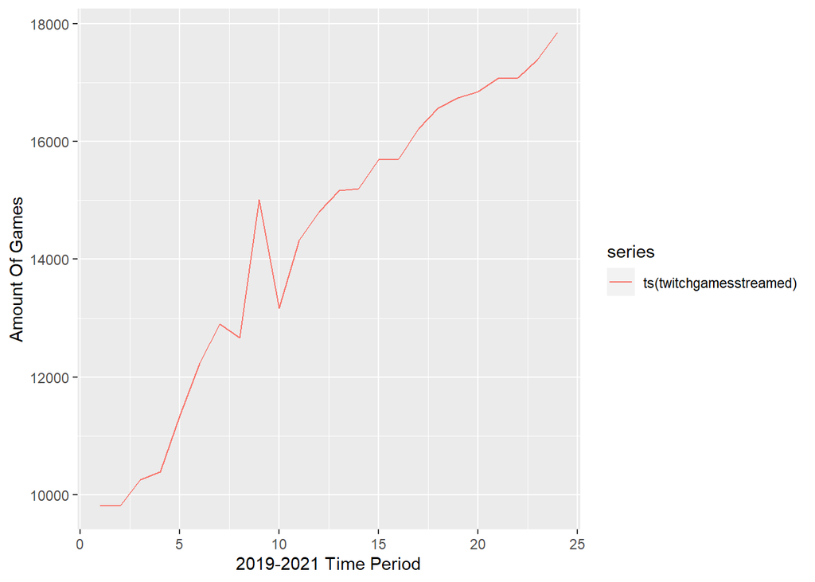

```r
ggplot()+
  geom_line() +
  autolayer(ts(twitchgamesstreamed))+
       xlab("2019-2021 Time Period")+
       ylab("Amount Of Games")
```

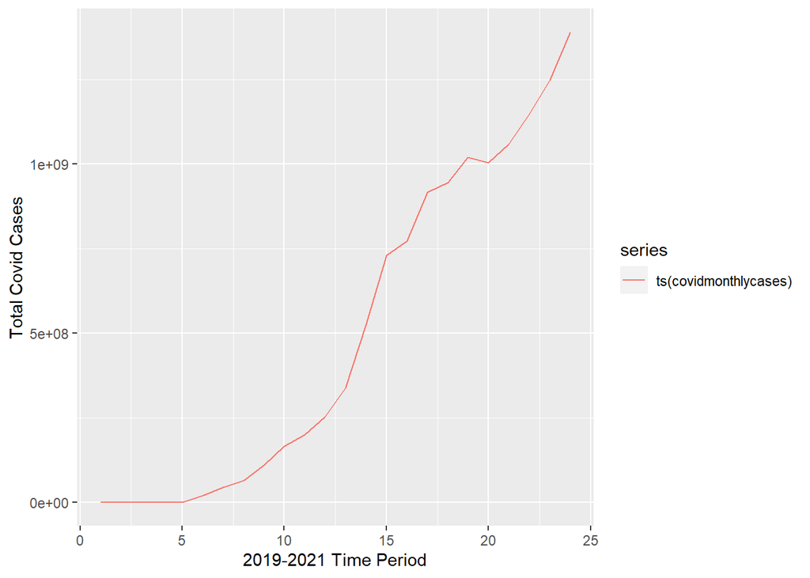

```r
ggplot()+
  autolayer(ts(covidmonthlycases))+
       xlab("2019-2021 Time Period")+
  ylab("Total Covid Cases")
```

I first plotted out most of my data to see what is happening, here is just a few. While I commented out the others as they presented no information that was relevant.

# Future Scenarios

So lets fit a linear model for Covid cases and Twitch Games Streamed.

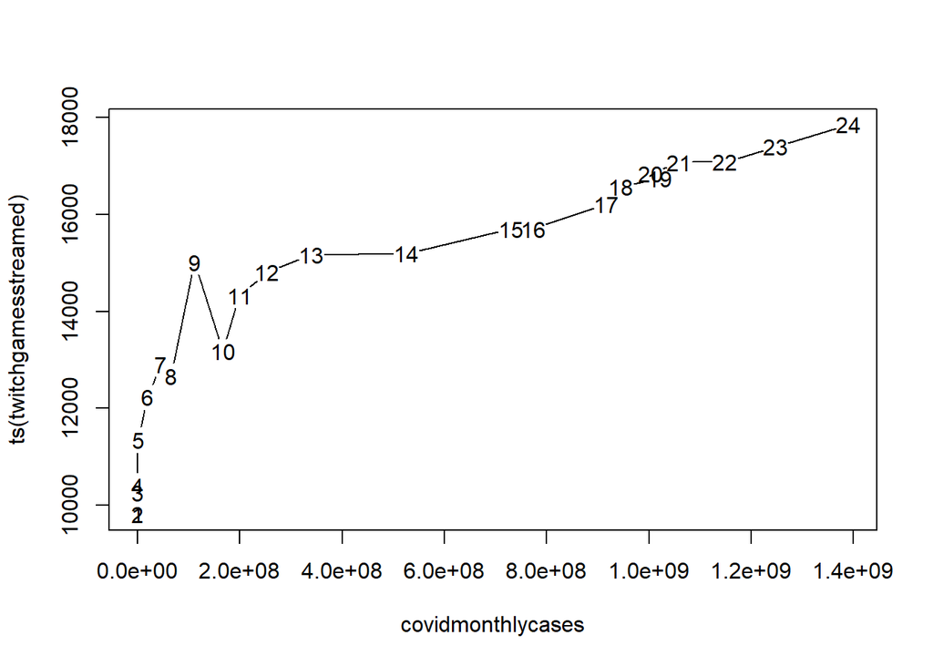

```r
plot(ts(twitchgamesstreamed)~covidmonthlycases)
```

```r
mod = lm(twitchgamesstreamed~covidmonthlycases)
mod$coefficients
```

```
##       (Intercept) covidmonthlycases
##      1.195618e+04      4.793849e-06
```

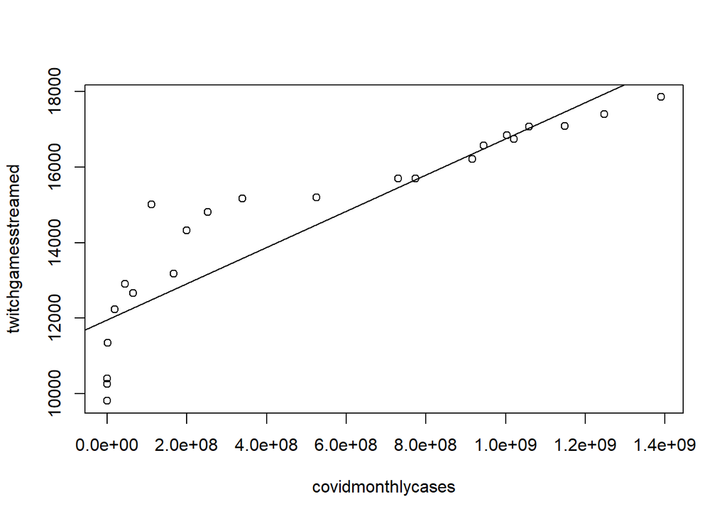

```
## integer(0)
```

```r
plot(twitchgamesstreamed~covidmonthlycases) + abline(mod$coefficients)
```

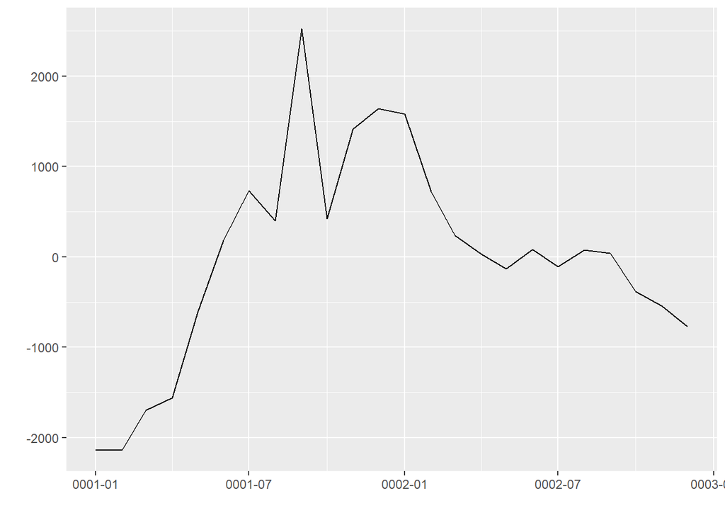

```r
modRes = ts(mod$residuals,frequency = 12)
autoplot(modRes)
```

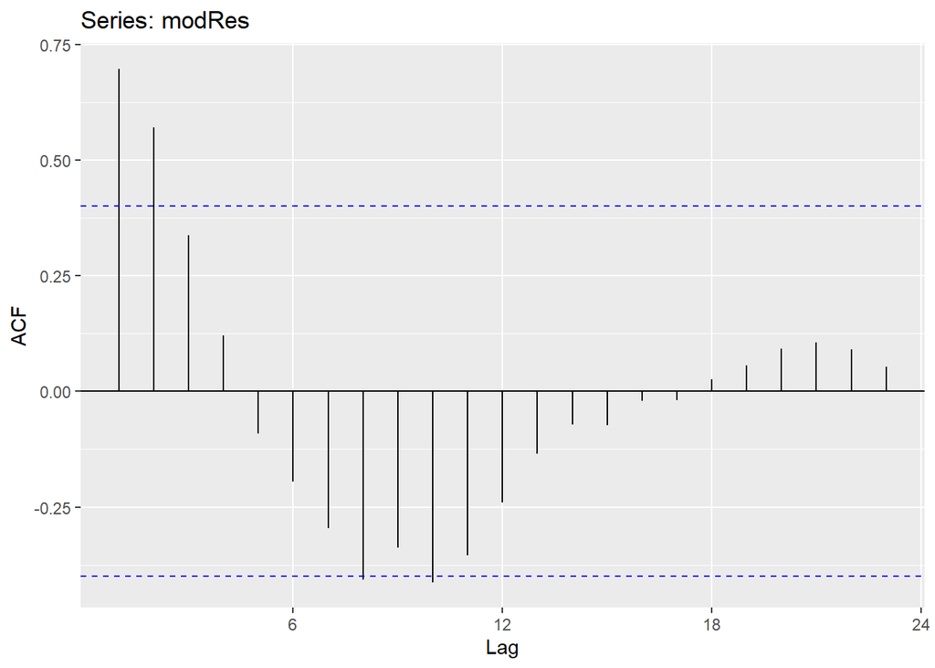

```r
ggAcf(modRes)
```

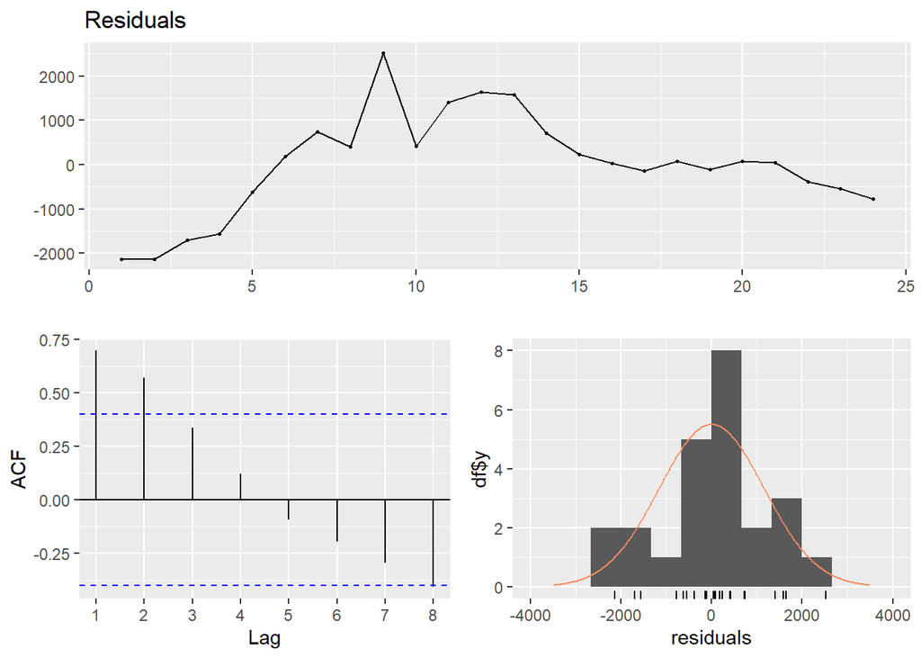

```
##
##  Breusch-Godfrey test for serial correlation of order up to 5
##
## data:  Residuals
## LM test = 13.848, df = 5, p-value = 0.01661
```

```r
checkresiduals(mod)
```

So we can see that as Covid cases go up, so does twitch games streamed. The linear fit looks fine to me, with the residuals containing some auto correlation. The residuals are stationary.

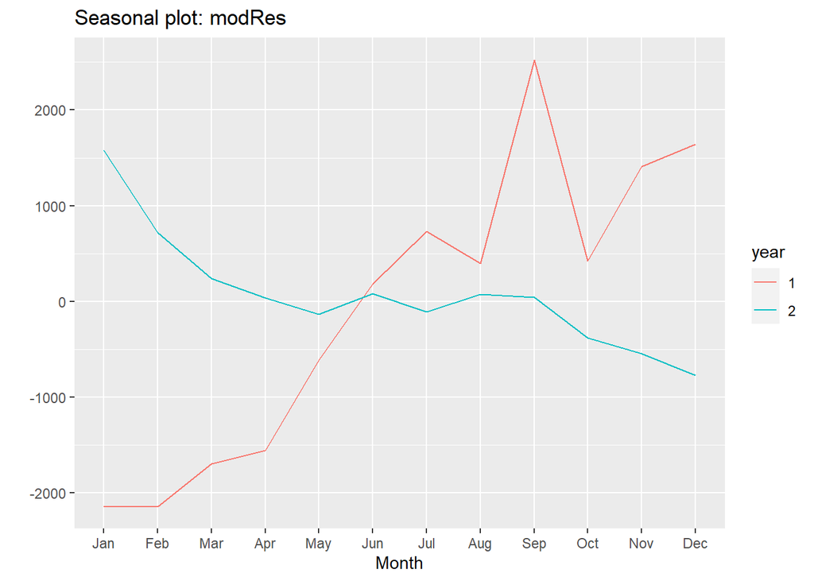

```r
ggseasonplot(modRes)
```

```r
modRes %>% ur.kpss() %>% summary()
```

```
##
## #######################
## # KPSS Unit Root Test #
## #######################
##
## Test is of type: mu with 2 lags.
##
## Value of test-statistic is: 0.2383
##
## Critical value for a significance level of:
##                 10pct  5pct 2.5pct  1pct
## critical values 0.347 0.463  0.574 0.739
```

```r
metaMod = auto.arima(modRes)
summary(metaMod)
```

```
## Series: modRes
## ARIMA(1,0,0) with zero mean
##
## Coefficients:
##          ar1
##       0.7926
## s.e.  0.1298
##
## sigma^2 estimated as 561938:  log likelihood=-192.91
## AIC=389.82   AICc=390.39   BIC=392.17
##
## Training set error measures:
##                    ME     RMSE      MAE      MPE     MAPE      MASE       ACF1
## Training set 9.304276 733.8416 517.4617 18.67533 120.6305 0.3182923 -0.2748545
```

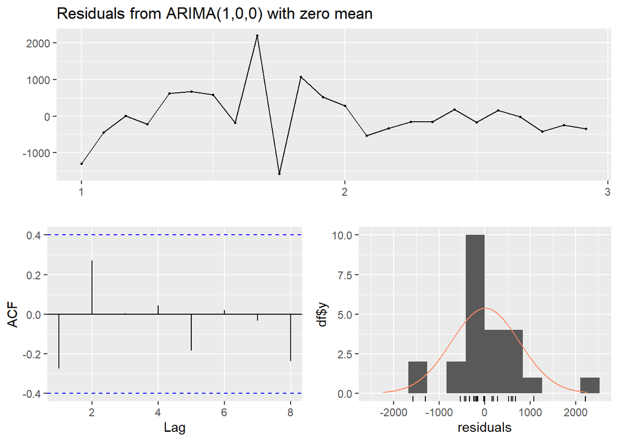

```
##
##  Ljung-Box test
##
## data:  Residuals from ARIMA(1,0,0) with zero mean
## Q* = 5.2787, df = 4, p-value = 0.2599
##
## Model df: 1.   Total lags used: 5
```

```r
checkresiduals(metaMod)
```

Combine them together assuming the covid monthly cases don’t change over the next time period.

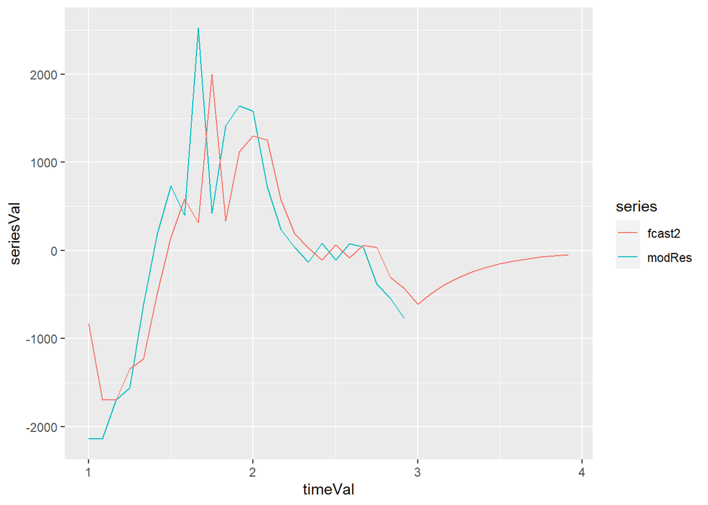

```r
ggplot() +
  autolayer(modRes) +
  autolayer(fcast2)
```

This is a huge improvement. Check the residuals to see!

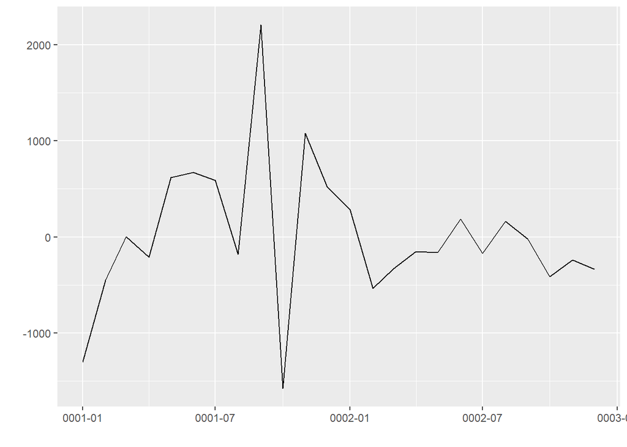

```r
totalRes = -(fcastA$fitted + fcastB$fitted - twitchgamesstreamed)
autoplot(totalRes)
```

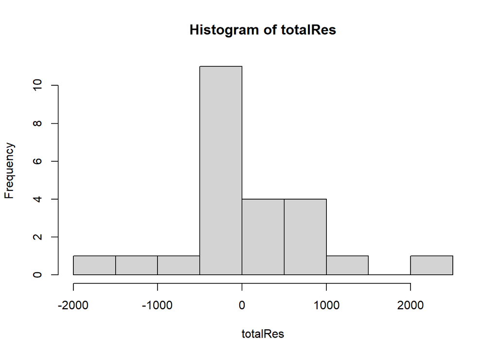

```r
hist(totalRes)
```

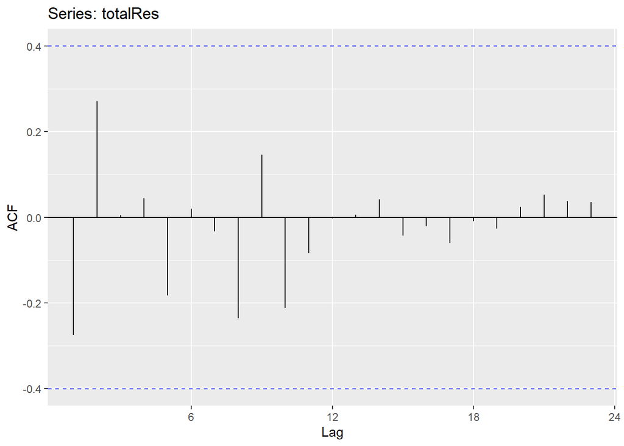

```r
ggAcf(totalRes)
```

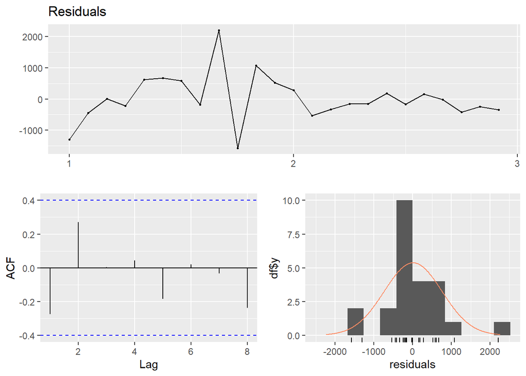

```r
checkresiduals(totalRes)
```

No Auto Correlation, Constant Variance, and Normal Results. Nothing jumps outside of the 95% bounds on the ACF, so we are looking good. Granted its a smaller dataset, it’s the best thing we could access.

# Holt’s Method

Let’s try HOLT’s Method really quick and see what we get.

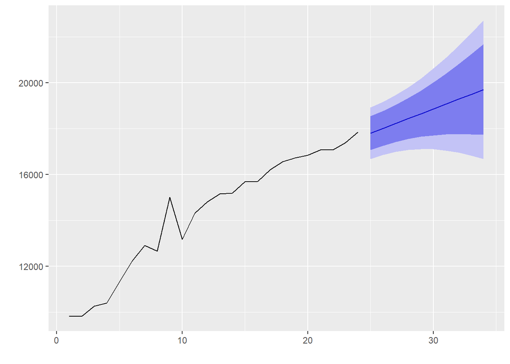

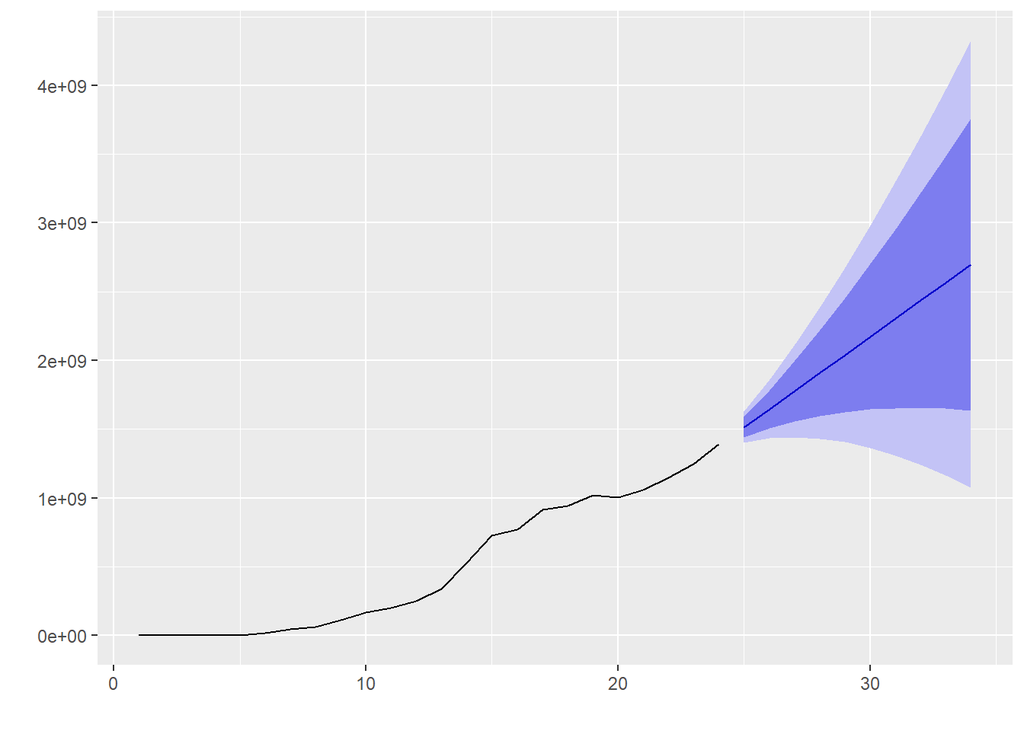

Interesting that covid cases 95% interval bounds open up alot more the further out we predict. Alright, lets move on.

Lets plug in a few more categories and see what we have for predictability from other data inside of a GGPairs.

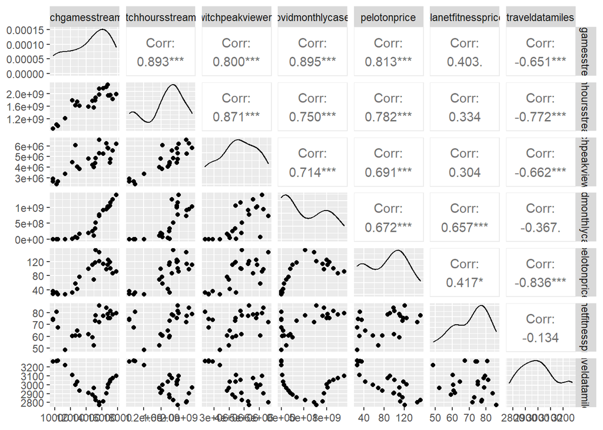

```r
allData = data.frame(twitchgamesstreamed,twitchhoursstreamed,twitchpeakviewers,covidmonthlycases,pelotonprice,planetfitnessprice,traveldatamiles)
GGally::ggpairs(allData[,1:7])
```

Things that stick out for me here:

Twitch Games Streamed and Hours Streamed Twitch Games Streamed and Monthly Covid Cases (0.895) Twitch Games Streamed and Peloton Price Covid Monthly Cases and Travel Data Miles

Obviously, we are mainly focusing on Twitch Games Streamed and what correlates there.

We gathered a ton of things from our GGPairs, lets start to apply them below.

First, I am going to throw together some ARIMA forecasts on my Games Streamed, and Peak Viewers categories as they interested me the most.